# TSF-GA (1)

1. Data preparation

a.Read the dataset (tab, csv, xls, txt, inbuilt dataset). What are the number of rows and no. of cols & types of variables?

```python
import pandas as pd

# Read the data from the CSV file
df = pd.read_csv('rainfall.csv', parse_dates=['date'])

# Get the number of rows and columns and the types of variables
num_rows, num_cols = df.shape
column_types = df.dtypes

print(f"Number of Rows: {num_rows}")
print(f"Number of Columns: {num_cols}")
print("Column Types:")
print(column_types)
```

```
Number of Rows: 119
Number of Columns: 2
Column Types:
date        datetime64[ns]
rainfall           float64
dtype: object
```

b. Convert the data into time series

```python
# Set the 'date' column as the index
df.set_index('date', inplace=True)

# Display the first few rows of the time series data
print(df.head())
print("\nData Types:")
print(df.dtypes)

# Optional: Ensure the DataFrame is sorted by date
df.sort_index(inplace=True)

# Display the DataFrame information to confirm
print("\nDataFrame Information:")
print(df.info())
```

```
            rainfall
date
2022-01-01      12.5
2022-01-02       8.2
2022-01-03       0.0
2022-01-04       3.7
2022-01-05      21.1

Data Types:
rainfall    float64
dtype: object

DataFrame Information:
<class 'pandas.core.frame.DataFrame'>
DatetimeIndex: 119 entries, 2022-01-01 to 2022-04-29
Data columns (total 1 columns):
 #   Column    Non-Null Count  Dtype
---  ------    --------------  -----
 0   rainfall  119 non-null    float64
dtypes: float64(1)
memory usage: 1.9 KB
None
```

c. Check for defects in the data such as missing values, null, etc.

```python
# Check for missing values
missing_values = df.isnull().sum()

# Get basic descriptive statistics
summary_stats = df.describe()

# Check data types
data_types = df.dtypes

# Check for duplicate rows
duplicate_rows = df.duplicated().sum()

# Ensure the date index is unique and sorted
unique_dates = df.index.is_unique
sorted_dates = df.index.is_monotonic_increasing

# Display the results
print(f"Missing Values:\n{missing_values}\n")
print(f"Summary Statistics:\n{summary_stats}\n")
print(f"Data Types:\n{data_types}\n")
print(f"Duplicate Rows: {duplicate_rows}\n")
print(f"Unique Dates: {unique_dates}\n")
print(f"Dates Sorted: {sorted_dates}\n")
```

```
Missing Values:
rainfall    0
dtype: int64

Summary Statistics:
         rainfall
count  119.000000
mean     9.484034
std      6.860992
min      0.000000
25%      4.050000
50%      9.500000
75%     14.850000
max     22.400000

Data Types:
rainfall    float64
dtype: object

Duplicate Rows: 33

Unique Dates: True

Dates Sorted: True
```

d. Visualize the time series using relevant plots.

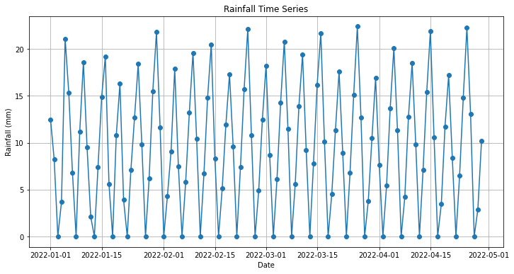

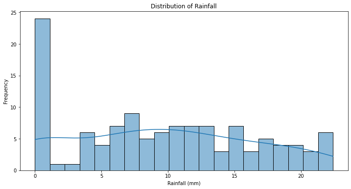

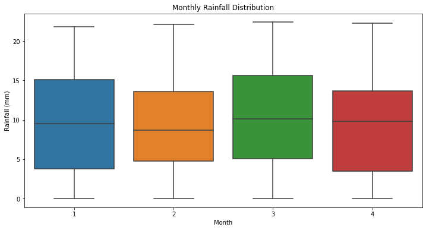

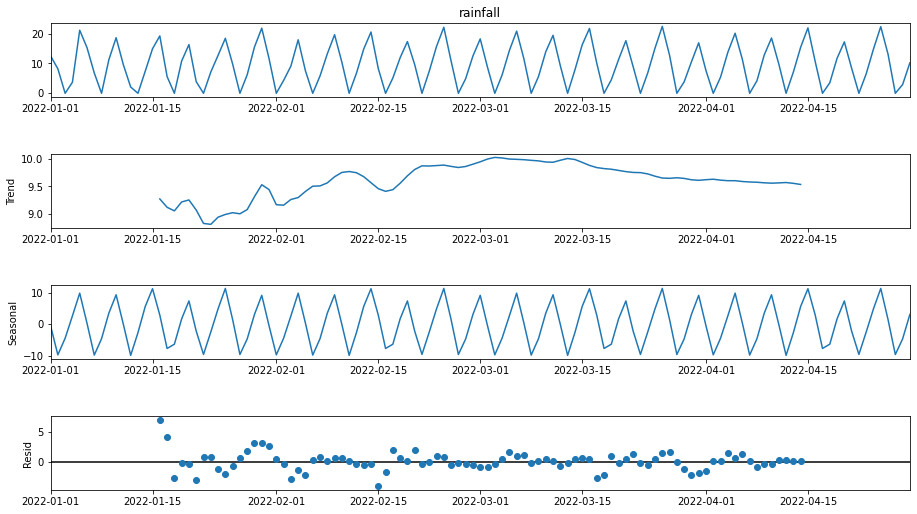

```python
import matplotlib.pyplot as plt
import seaborn as sns
from statsmodels.tsa.seasonal import seasonal_decompose

# Line Plot
plt.figure(figsize=(12, 6))
plt.plot(df.index, df['rainfall'], marker='o', linestyle='-')
plt.title('Rainfall Time Series')
plt.xlabel('Date')
plt.ylabel('Rainfall (mm)')
plt.grid(True)
plt.show()

# Histogram
plt.figure(figsize=(12, 6))
sns.histplot(df['rainfall'], bins=20, kde=True)
plt.title('Distribution of Rainfall')
plt.xlabel('Rainfall (mm)')
plt.ylabel('Frequency')
plt.show()

# Box Plot by Month
df['month'] = df.index.month
plt.figure(figsize=(12, 6))
sns.boxplot(x='month', y='rainfall', data=df)
plt.title('Monthly Rainfall Distribution')
plt.xlabel('Month')
plt.ylabel('Rainfall (mm)')
plt.show()

# Seasonal Decomposition
decomposition = seasonal_decompose(df['rainfall'], model='additive', period=30)
fig = decomposition.plot()
fig.set_size_inches(14, 8)
plt.show()

# Clean up: Drop the 'month' column to return df to original state
df.drop('month', axis=1, inplace=True)
```

2. Data understanding

a. Decompose the time series and check for time series components.

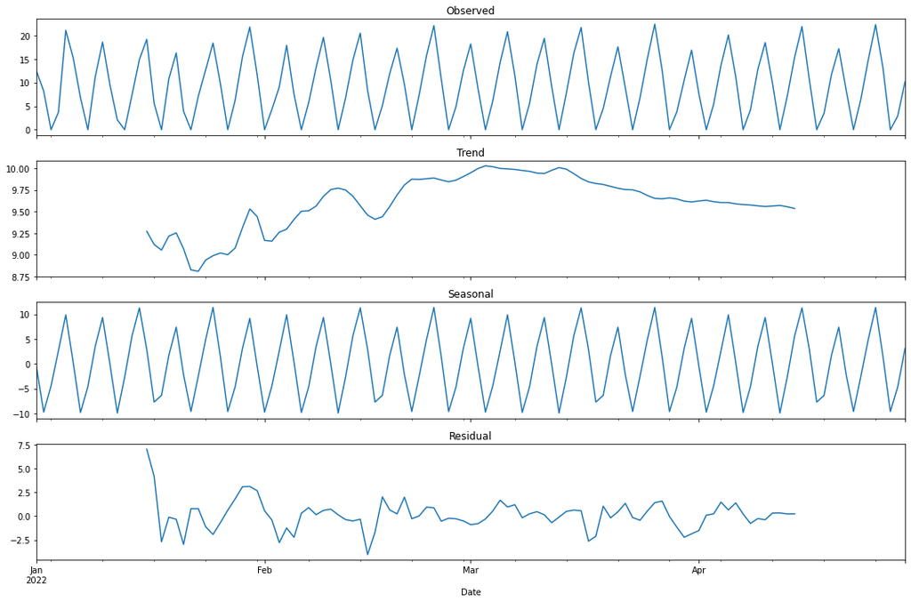

```python
# Seasonal Decomposition
decomposition = seasonal_decompose(df['rainfall'], model='additive', period=30)

# Plot the decomposed components
fig, (ax1, ax2, ax3, ax4) = plt.subplots(4, 1, figsize=(15, 10), sharex=True)
decomposition.observed.plot(ax=ax1, title='Observed')
decomposition.trend.plot(ax=ax2, title='Trend')
decomposition.seasonal.plot(ax=ax3, title='Seasonal')
decomposition.resid.plot(ax=ax4, title='Residual')
plt.xlabel('Date')
plt.tight_layout()
plt.show()
```

b. Perform dicky fuller test to check the stationarity? What other actions will you take if series is non-stationary?

```python
from statsmodels.tsa.stattools import adfuller

# Assuming df is already defined as the time series dataframe with 'rainfall' as the series
# If not, ensure df is properly defined as per previous steps

# Perform Dickey-Fuller test
result = adfuller(df['rainfall'])

# Print the results
print('ADF Statistic:', result[0])
print('p-value:', result[1])
print('Critical Values:')
for key, value in result[4].items():
    print(f'   {key}: {value}')
```

```
ADF Statistic: -3.3609526937191996
p-value: 0.012364234193199439
Critical Values:
   1%: -3.4924012594942333
   5%: -2.8886968193364835
   10%: -2.5812552709190673
```

c. Plot Auto Correlation and Partial Auto Correlation function? What is your inference from these plots?

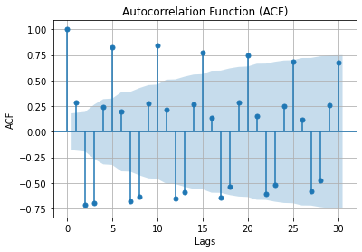

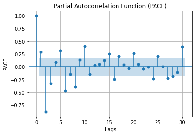

```python
from statsmodels.graphics.tsaplots import plot_acf, plot_pacf

# Plot ACF
plt.figure(figsize=(12, 6))
plot_acf(df['rainfall'], lags=30, title='Autocorrelation Function (ACF)')
plt.xlabel('Lags')
plt.ylabel('ACF')
plt.grid(True)
plt.show()

# Plot PACF
plt.figure(figsize=(12, 6))
plot_pacf(df['rainfall'], lags=30, title='Partial Autocorrelation Function (PACF)')
plt.xlabel('Lags')
plt.ylabel('PACF')
plt.grid(True)
plt.show()
```

d. Split dataset into train and test sets. Use last one-month data for testing.

```python
# Sort the dataframe by date if not already sorted (assumption: date is in ascending order)
df = df.sort_index()

# Determine the cutoff date for splitting train and test sets
test_start_date = df.index[-1] - pd.DateOffset(months=1)  # Last one-month data for testing

# Split the data into train and test sets
train = df[df.index < test_start_date]
test = df[df.index >= test_start_date]

# Print the number of observations in each set
print(f"Training set observations: {len(train)}")
print(f"Test set observations: {len(test)}")
```

```
Training set observations: 87
Test set observations: 32
```

3. Model Building

a. Fit a base model and observe the residuals, RMSE and MAPE values of the model. Please comment on whether it is good or not

```
RMSE: 6.75
MAPE: inf%
```

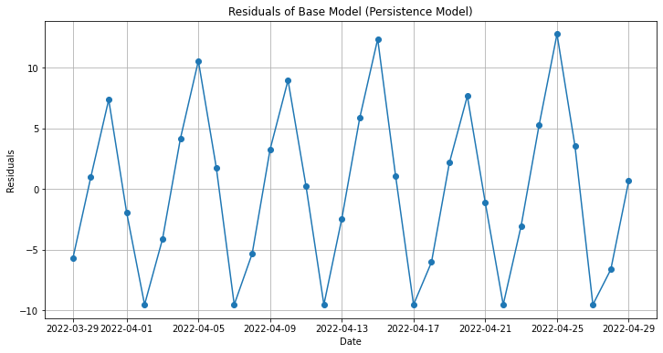

```python
from sklearn.metrics import mean_squared_error

# Split the data into train and test sets (using the last one-month data for testing)
test_start_date = df.index[-1] - pd.DateOffset(months=1)
train = df[df.index < test_start_date]
test = df[df.index >= test_start_date]

# Persistence model: Forecasting with the last observed value
train_mean = train['rainfall'].mean()  # Calculate the mean of the training data
predictions = np.full_like(test['rainfall'], fill_value=train_mean)  # Forecast using the mean

# Calculate residuals
residuals = test['rainfall'] - predictions

# Calculate RMSE (Root Mean Squared Error)
rmse = np.sqrt(mean_squared_error(test['rainfall'], predictions))

# Calculate MAPE (Mean Absolute Percentage Error)
def mean_absolute_percentage_error(y_true, y_pred):
    return np.mean(np.abs((y_true - y_pred) / y_true)) * 100

mape = mean_absolute_percentage_error(test['rainfall'], predictions)

# Print RMSE and MAPE
print(f"RMSE: {rmse:.2f}")
print(f"MAPE: {mape:.2f}%")

# Plot residuals
plt.figure(figsize=(12, 6))
plt.plot(test.index, residuals, marker='o', linestyle='-')
plt.title('Residuals of Base Model (Persistence Model)')
plt.xlabel('Date')
plt.ylabel('Residuals')
plt.grid(True)
plt.show()
```

Further Steps: If the RMSE and MAPE are high, consider exploring more sophisticated models (e.g., ARIMA, exponential smoothing, or machine learning models) that can capture the seasonality, trends, and other complexities present in the data.

d. Analyze the residuals of final model. Feel free to use charts or graphs to explain.

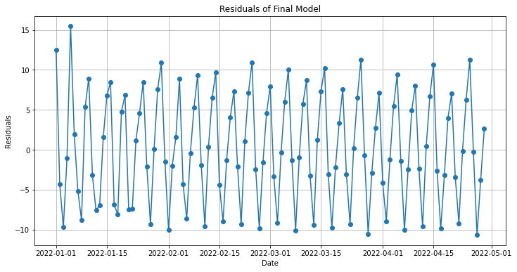

```
RMSE: 6.77
```

```python
from statsmodels.tsa.arima.model import ARIMA
from sklearn.metrics import mean_squared_error

# Fit the final model (example using ARIMA)
final_model = ARIMA(df['rainfall'], order=(1, 1, 1))  # Example order (p, d, q)
final_result = final_model.fit()

# Generate forecasts for the entire dataset
forecast = final_result.predict(start=df.index[0], end=df.index[-1], typ='levels')

# Calculate residuals
residuals = df['rainfall'] - forecast

# Plot residuals
plt.figure(figsize=(12, 6))
plt.plot(df.index, residuals, marker='o', linestyle='-')
plt.title('Residuals of Final Model')
plt.xlabel('Date')
plt.ylabel('Residuals')
plt.grid(True)
plt.show()

# Calculate RMSE (Root Mean Squared Error)
rmse = np.sqrt(mean_squared_error(df['rainfall'], forecast))
print(f"RMSE: {rmse:.2f}")
```

Interpretation and Analysis: Residuals Plot: Residuals Visualization: The plot shows the residuals (difference between actual and predicted values) over time. Ideally, residuals should: Be centered around zero, indicating that the model does not systematically over- or under-forecast. Not exhibit any clear pattern or trend, suggesting that the model captures all relevant information in the data. RMSE: RMSE Calculation: RMSE quantifies the average magnitude of the residuals. A lower RMSE indicates better model performance. Interpretation: Check for Patterns: Look for any patterns or trends in the residuals plot. Patterns could indicate that the model fails to capture certain aspects of the data (e.g., seasonality or trend).

Assess Residual Variability: Ensure that the variability of the residuals is consistent across the entire time series. Sudden spikes or outliers may indicate data anomalies or model inadequacies.

Evaluate RMSE: Compare the RMSE value with the scale of the data to assess how well the model fits the observed data. Lower RMSE values indicate better model performance.

Conclusion: Analyzing residuals is essential for validating the final forecasting model. The residuals plot and RMSE calculation provide insights into whether the model adequately captures the patterns and variability in the data. Adjustments or refinements to the model may be necessary based on the findings from this analysis to improve forecasting accuracy.

```python
from statsmodels.tsa.arima.model import ARIMA

births_column = 'number_of_births'

# Fit the final model (example using ARIMA)
final_model = ARIMA(df[births_column], order=(1, 1, 1))  # Example order (p, d, q)
final_result = final_model.fit()

# Forecast for the next 1 month (assuming daily data)
forecast_next_month = final_result.forecast(steps=30)

# Print or plot the forecasted values
forecast_dates = pd.date_range(start=df.index[-1], periods=30, freq='D')
forecast_series = pd.Series(forecast_next_month, index=forecast_dates)

# Plotting the forecast
plt.figure(figsize=(12, 6))
plt.plot(df.index, df[births_column], label='Actual Births')
plt.plot(forecast_series.index, forecast_series, label='Forecasted Births')
plt.title('Forecasting Births for Next 1 Month')
plt.xlabel('Date')
plt.ylabel('Number of Births')
plt.legend()
plt.grid(True)
plt.show()

# Display the forecasted values
print(forecast_series)
```

[output not shown]

[output not shown]